# Updated Results Diagnostics

Daniel Reyes

3/22/2021

# Model 1: trait ~ mainland/island + year + (1|ID)

This model looks at the differences between *Tribulus* mericarps, flowers and leaves from mainland and island populations.

## Mericarp traits:

### Length

Best fitted data: Untransformed data

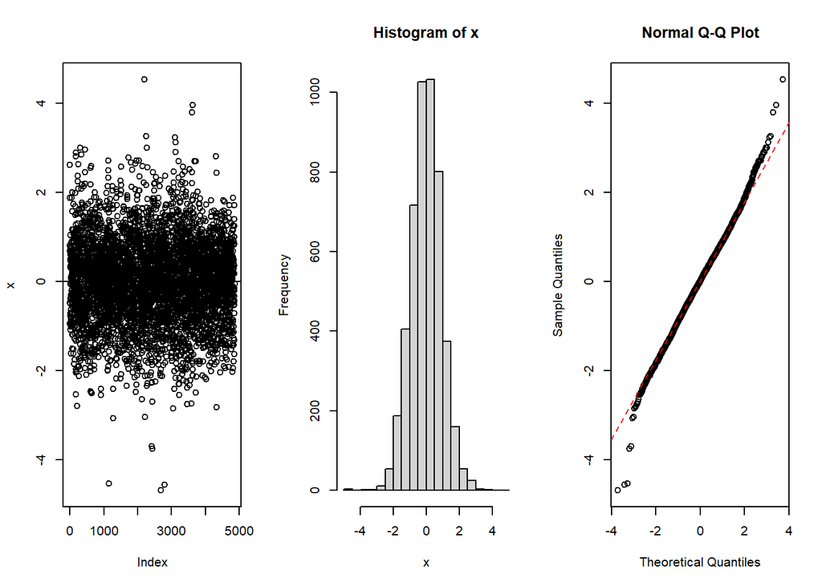

```
## [1] "Kurtosis=0.64698123476754"
## [1] "Skew=-0.0153024526537272"
```

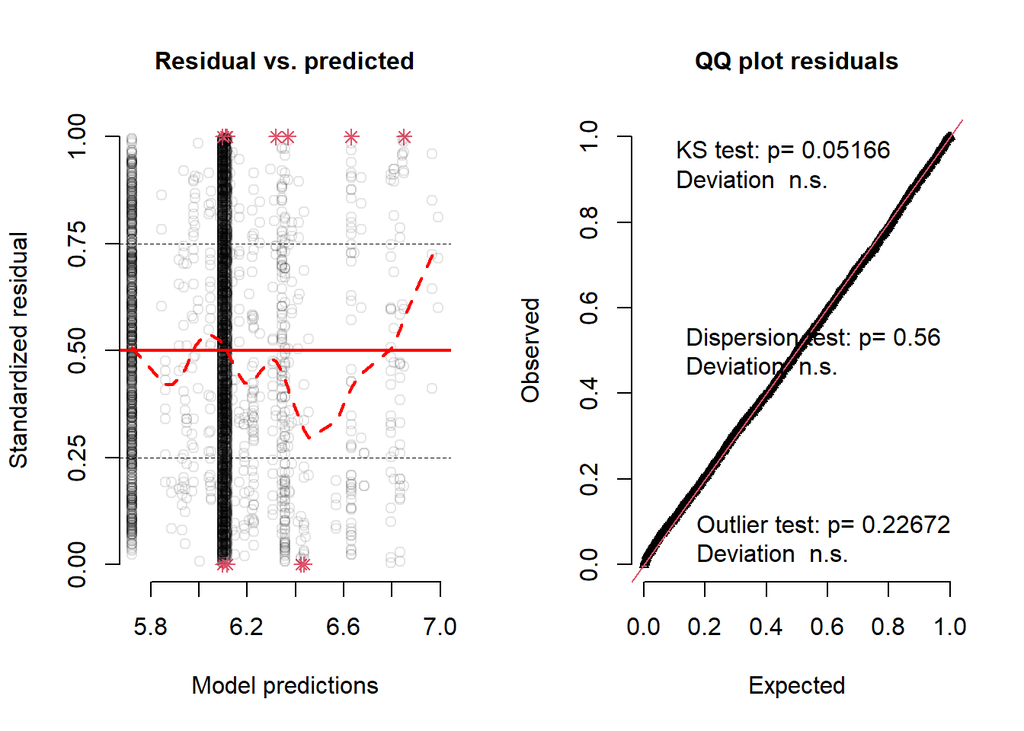

```
## Analysis of Deviance Table (Type II Wald chisquare tests)
##
## Response: length
##                  Chisq Df Pr(>Chisq)
## mainland_island 10.731  1   0.001054 **
## year_collected  10.827  1   0.001000 **
## ---
## Signif. codes:  0 '***' 0.001 '**' 0.01 '*' 0.05 '.' 0.1 ' ' 1
```

#### Emmeans: Length

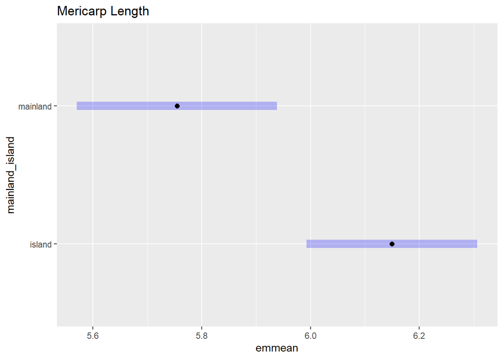

### Width

Best fitted data: Square root transformed data

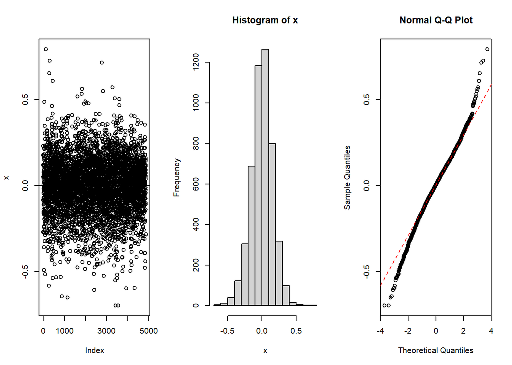

```
## [1] "Kurtosis=0.915288926843053"
## [1] "Skew=-0.184236416326029"
```

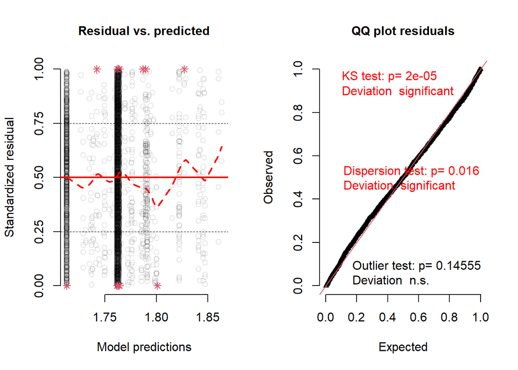

```
## Analysis of Deviance Table (Type II Wald chisquare tests)
##
## Response: sqrt(width)
##                 Chisq Df Pr(>Chisq)
## mainland_island 10.36  1   0.001288 **
## year_collected   7.84  1   0.005110 **
## ---
## Signif. codes:  0 '***' 0.001 '**' 0.01 '*' 0.05 '.' 0.1 ' ' 1
```

#### Emmeans: Width

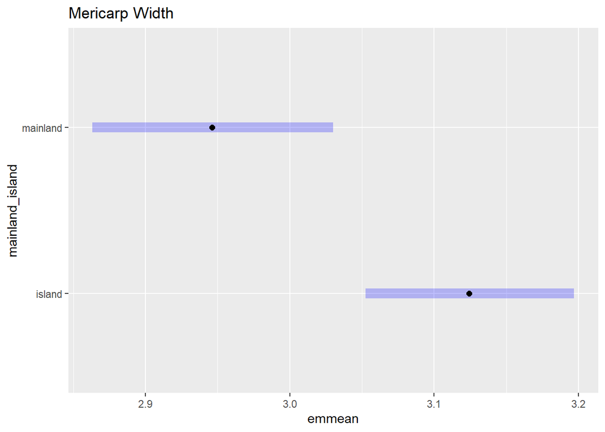

### Depth

Best fitted data: Untransformed data

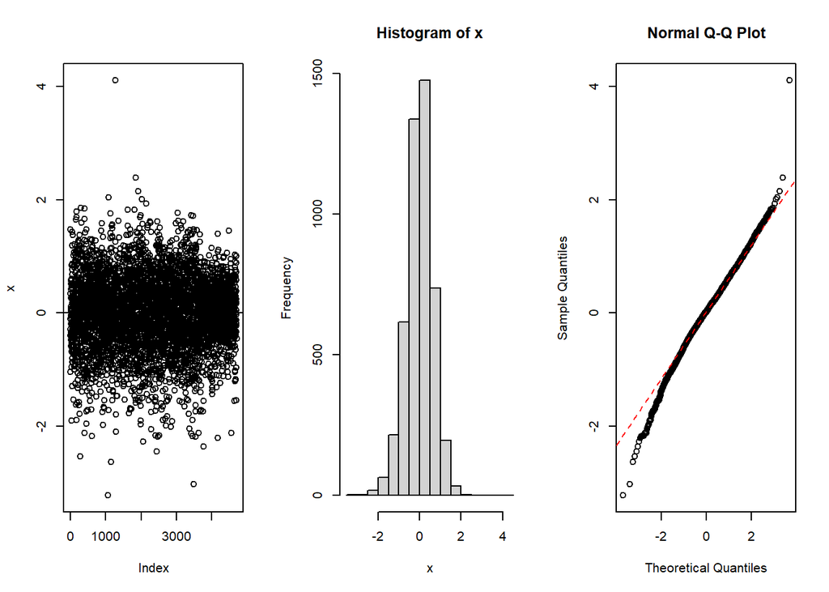

```
## [1] "Kurtosis=0.989267427953835"
## [1] "Skew=-0.241253118215469"
```

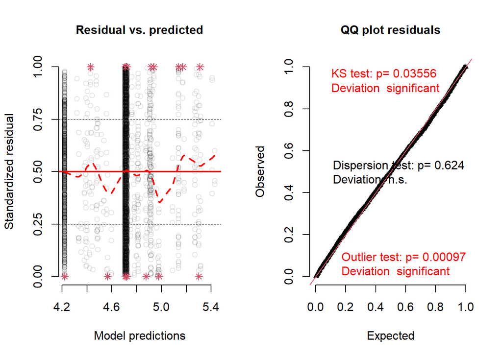

```
## Analysis of Deviance Table (Type II Wald chisquare tests)
##
## Response: depth
##                  Chisq Df Pr(>Chisq)
## mainland_island 50.871  1  9.865e-13 ***
## year_collected  20.387  1  6.325e-06 ***
## ---
## Signif. codes:  0 '***' 0.001 '**' 0.01 '*' 0.05 '.' 0.1 ' ' 1
```

#### Emmeans: Depth

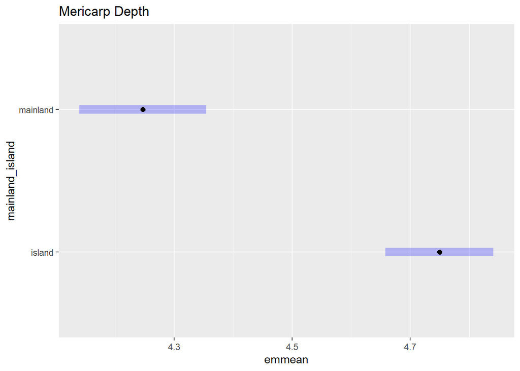

### Spine length

Spine length had a lot zeroes that were removed, also I filter the data again because the residual distribution was skewed. I removed spines larger than 10 mm. This filter removed some individuals from Baltra Island. Here I show the best model fit after filtering.

The histograms show the distribution of spine length measurements. The residual distribution of the unfiltered model, and the spine length distribution of the filtered data.

Best fitted data: Untransformed data.

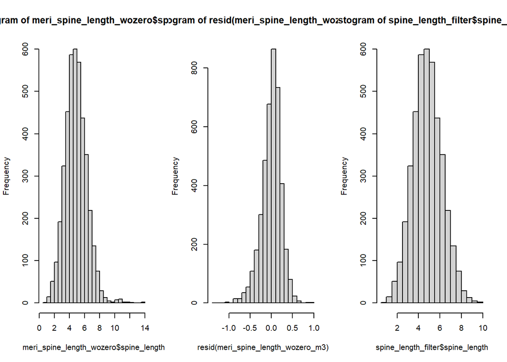

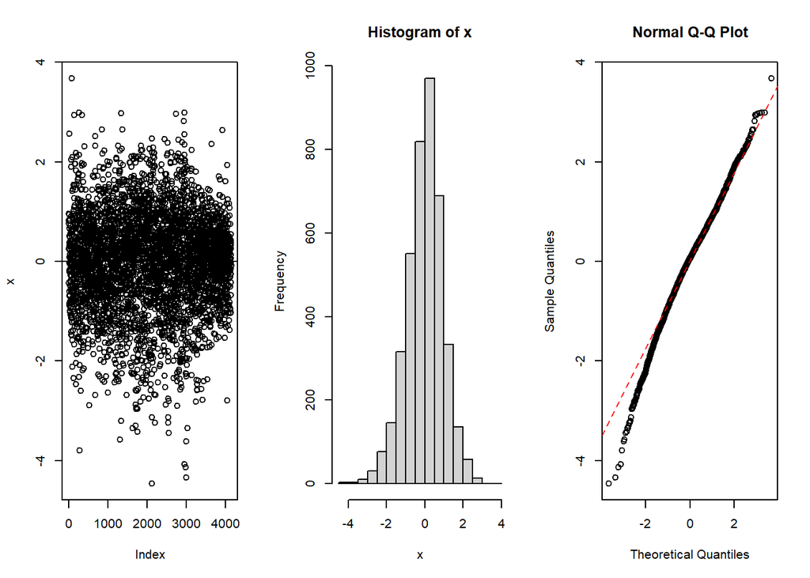

```
## [1] "Kurtosis=0.748351232224566"
## [1] "Skew=-0.359277318386279"
```

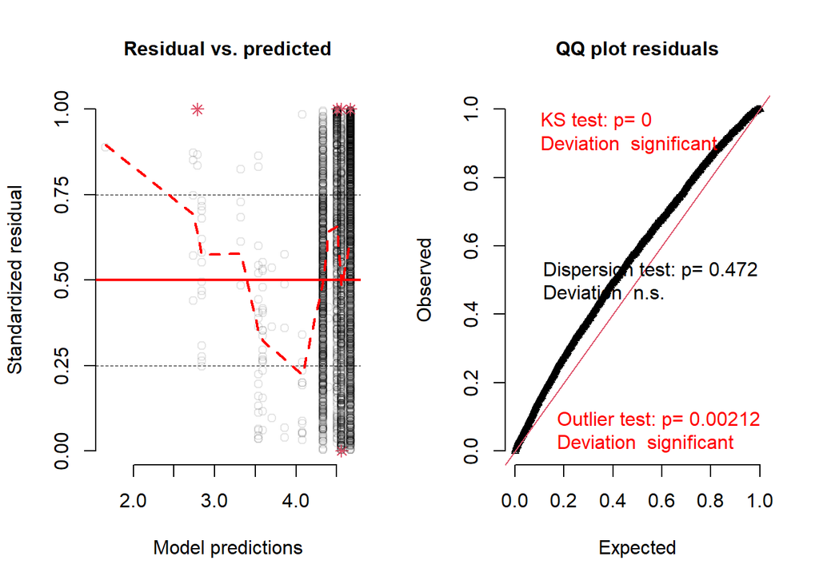

```
## Analysis of Deviance Table (Type II Wald chisquare tests)
##
## Response: spine_length
##                   Chisq Df Pr(>Chisq)
## mainland_island  2.1413  1     0.1434
## year_collected  25.6152  1  4.168e-07 ***
## ---
## Signif. codes:  0 '***' 0.001 '**' 0.01 '*' 0.05 '.' 0.1 ' ' 1
```

**Mainland/island groups non significant**

#### Emmeans: Spine length

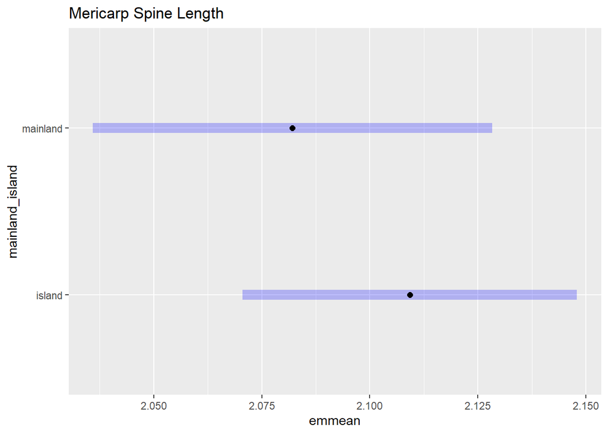

### Tip distance

In a similar way, tip distance had a lot zeroes that were removed. I show three histograms with the distributions of tip distance measurements with zeros included. The residuals of the original model and the residuals distribution after filtering.

Best fitted data: Untransformed data.

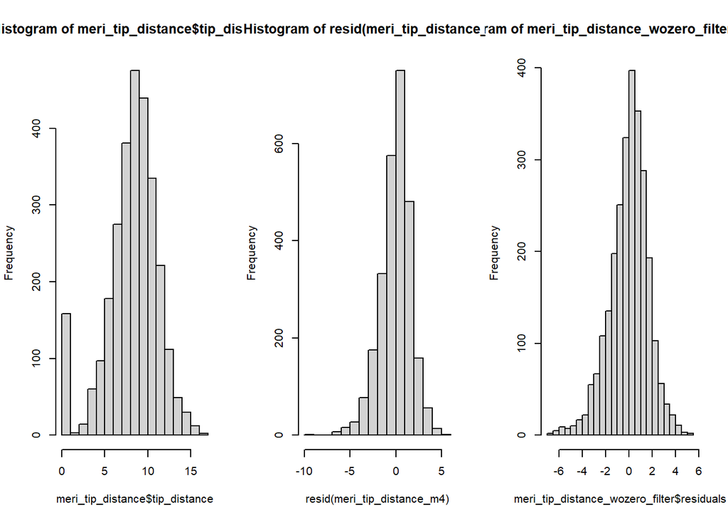

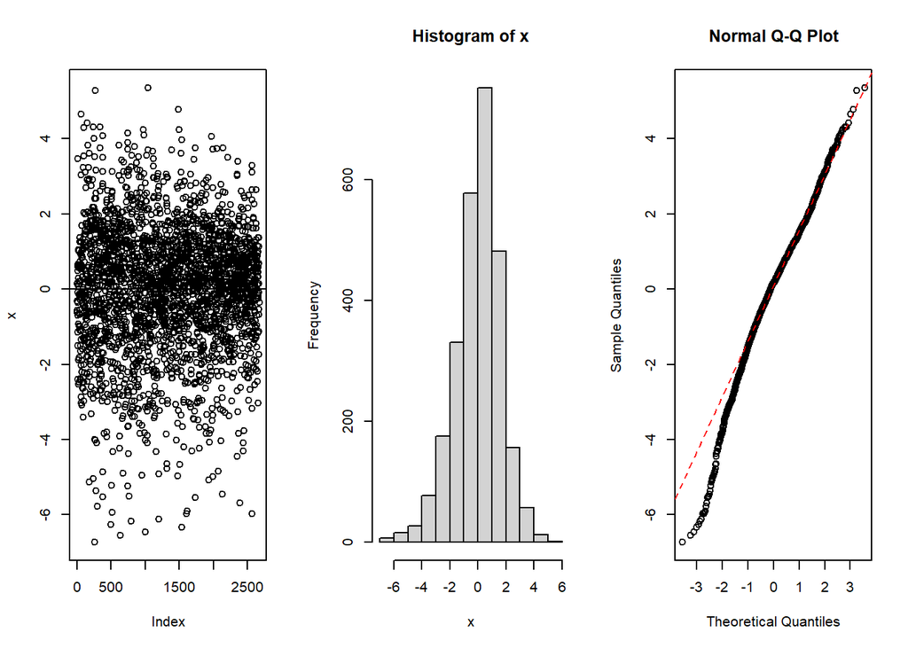

```
## [1] "Kurtosis=0.981641657570068"
## [1] "Skew=-0.521061407190251"
```

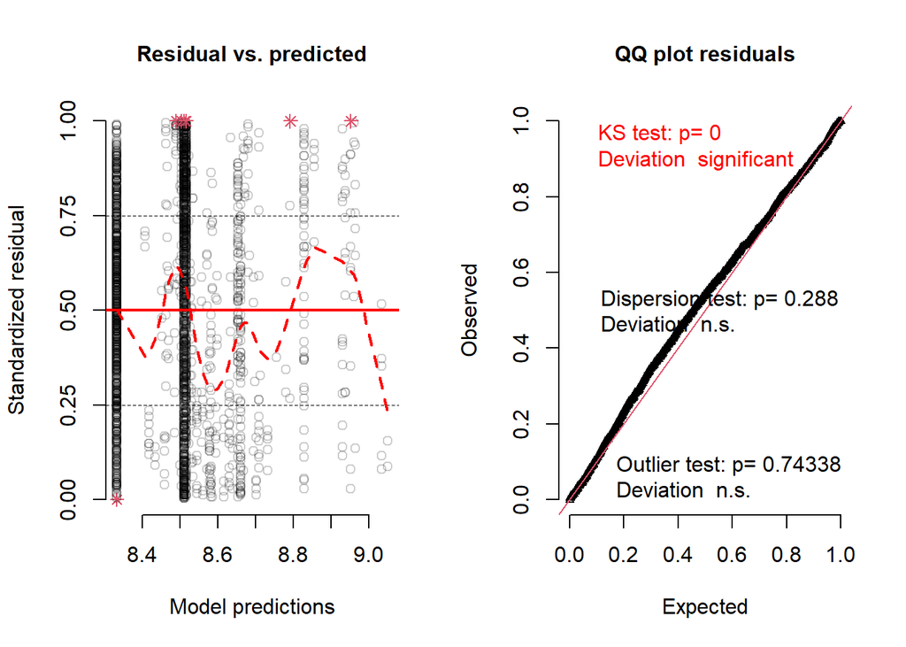

```
## Analysis of Deviance Table (Type II Wald chisquare tests)
##
## Response: tip_distance
##                  Chisq Df Pr(>Chisq)
## mainland_island 0.6821  1     0.4089
## year_collected  1.1957  1     0.2742
```

**Mainland/island groups non significant**

**Year groups non significant**

#### Emmeans: Tip distance

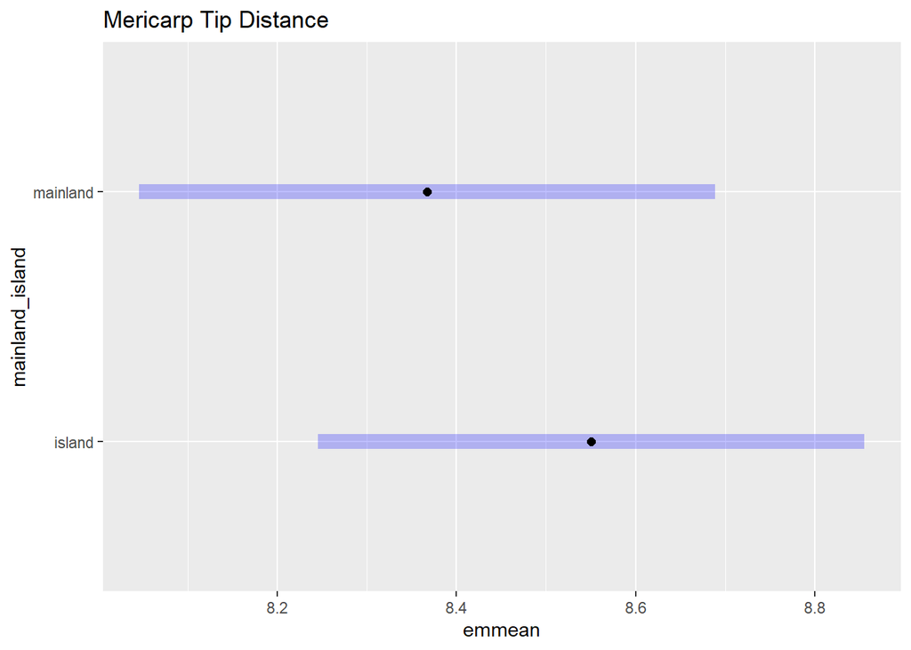

### Lower spines

This model includes year as a factor but does not contain ID as a random effect.

The second one using the *glmmTMB* package: **glmmTMB(lower_spines ~ mainland_island + (1|ID)**

The glmmTMB model does not include the year factor but does include the random ID effect.

```
## Analysis of Deviance Table (Type II tests)
##
## Response: lower_spines
##                 LR Chisq Df Pr(>Chisq)
## mainland_island   515.40  1  < 2.2e-16 ***
## year_collected     11.99  1  0.0005335 ***
## ---
## Signif. codes:  0 '***' 0.001 '**' 0.01 '*' 0.05 '.' 0.1 ' ' 1
```

```
## Analysis of Deviance Table (Type II Wald chisquare tests)
##
## Response: lower_spines
##                  Chisq Df Pr(>Chisq)
## mainland_island 73.898  1  < 2.2e-16 ***
## ---
## Signif. codes:  0 '***' 0.001 '**' 0.01 '*' 0.05 '.' 0.1 ' ' 1
```

#### Emmeans: Lower spines

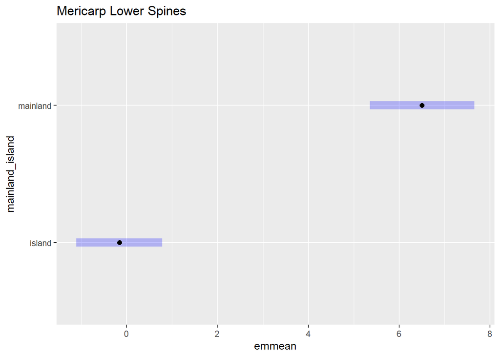

First plot, glm model. Second plot, glmmTMB model.

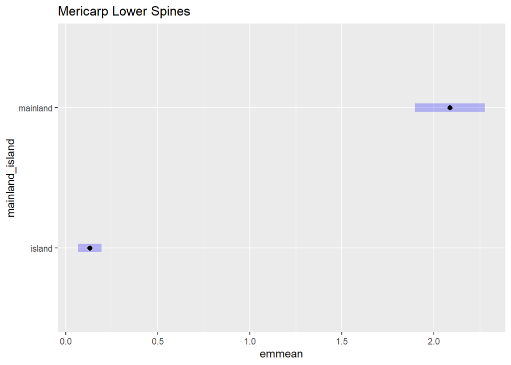

First plot, glm model. Second plot, glmmTMB model.

### Upper spines

Presence/absence of upper spines is a binomial trait that replaced spine number. Similar as lower spines, I used two models that showed different outcomes. The first one is a glm: **glm(upper_spines ~ mainland_island + year_collected)**.

This model includes year as a factor but does not contain ID as a random effect.

The second one using the *glmmTMB* package: **glmmTMB(upper_spines ~ mainland_island + (1|ID)**

The glmmTMB model does not include the year factor but does include the random ID effect.

```
## Analysis of Deviance Table (Type II tests)
##
## Response: upper_spines
##                 LR Chisq Df Pr(>Chisq)
## mainland_island   94.046  1  < 2.2e-16 ***
## year_collected    34.208  1  4.953e-09 ***
## ---
## Signif. codes:  0 '***' 0.001 '**' 0.01 '*' 0.05 '.' 0.1 ' ' 1
```

```
## Analysis of Deviance Table (Type II Wald chisquare tests)
##
## Response: upper_spines
##                  Chisq Df Pr(>Chisq)
## mainland_island 0.6146  1      0.433
```

**Here, for the glm model the results are significant, but for the glmmTMB the differences between mainland and island populations are not signigicant.**

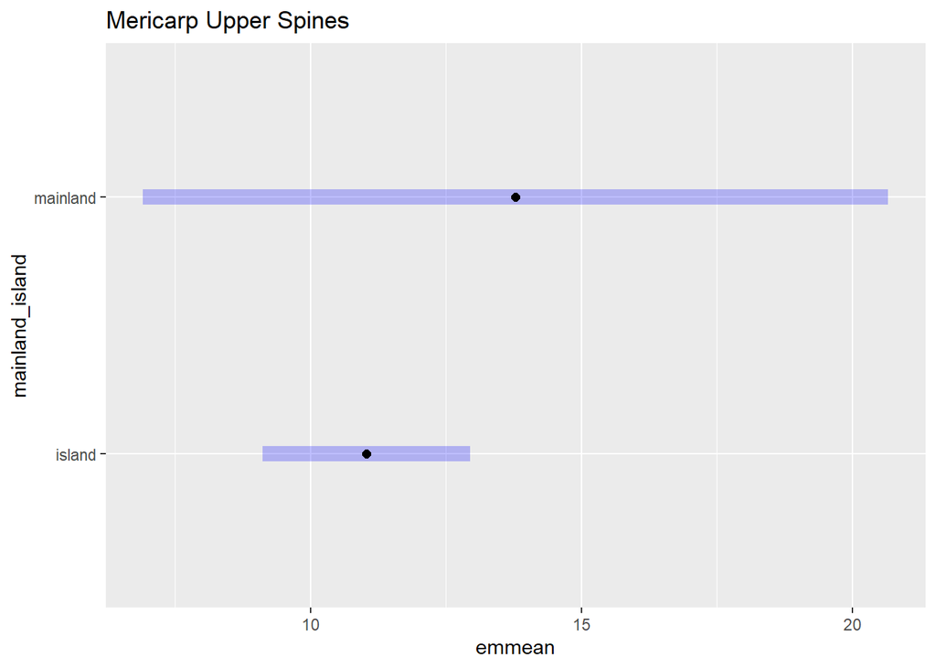

First plot, glm model. Second plot, glmmTMB model.

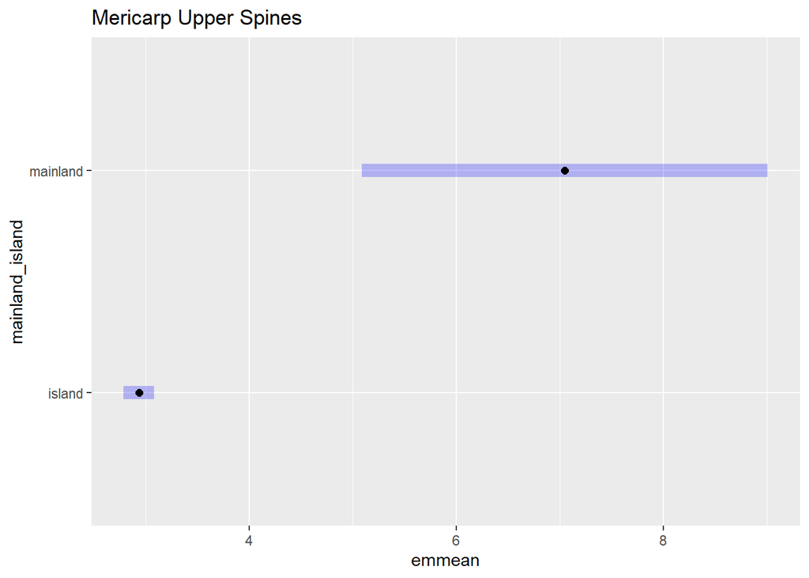

First plot, glm model. Second plot, glmmTMB model.

## Flower traits:

### Petal length

Best fitted data: Untransformed data Filter residuals. This filter removed specimens 240, 351, 320 (<-5) and 454, 319, 207, 249, 340 (>5)

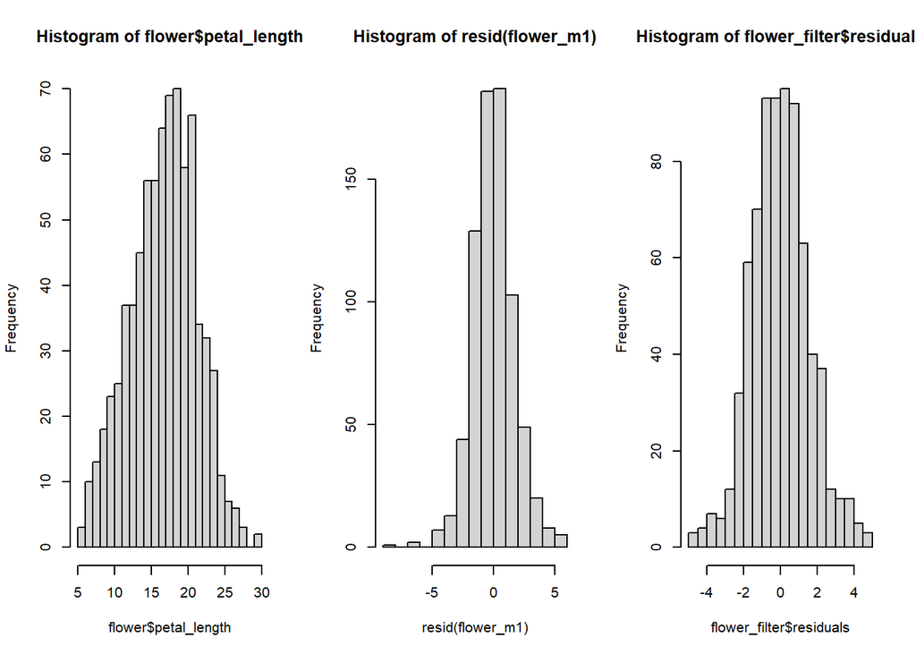

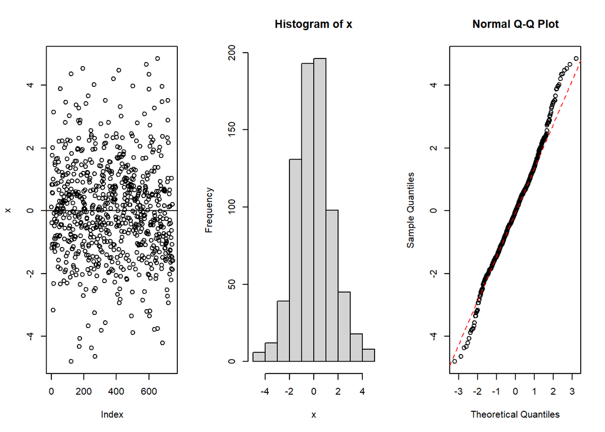

```
## [1] "Kurtosis=0.548589780356622"
## [1] "Skew=0.149144911337373"
```

```
## qu = 0.75, log(sigma) = -2.582137 : outer Newton did not converge fully.
```

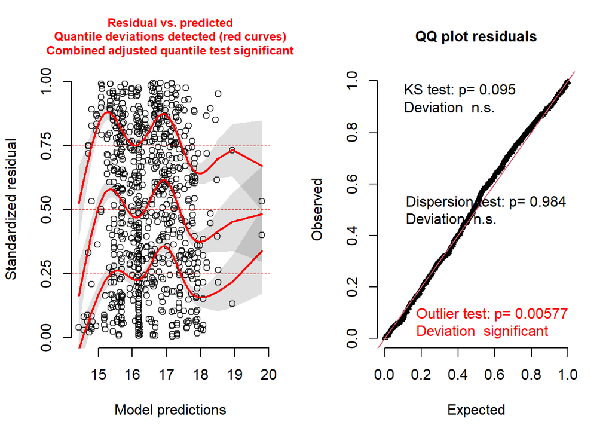

```
## Analysis of Deviance Table (Type II Wald chisquare tests)
##
## Response: petal_length
##                   Chisq Df Pr(>Chisq)
## mainland_island  1.0773  1     0.2993
## year_collected  15.8995  1   6.68e-05 ***
## ---
## Signif. codes:  0 '***' 0.001 '**' 0.01 '*' 0.05 '.' 0.1 ' ' 1
```

**Mainland and island differences are not significant. Year differences are significant.**

#### Emmeans: Petal length

[figure not shown]

## Leaf traits:

### Leaf length

Best fitted data: Square root transformed data

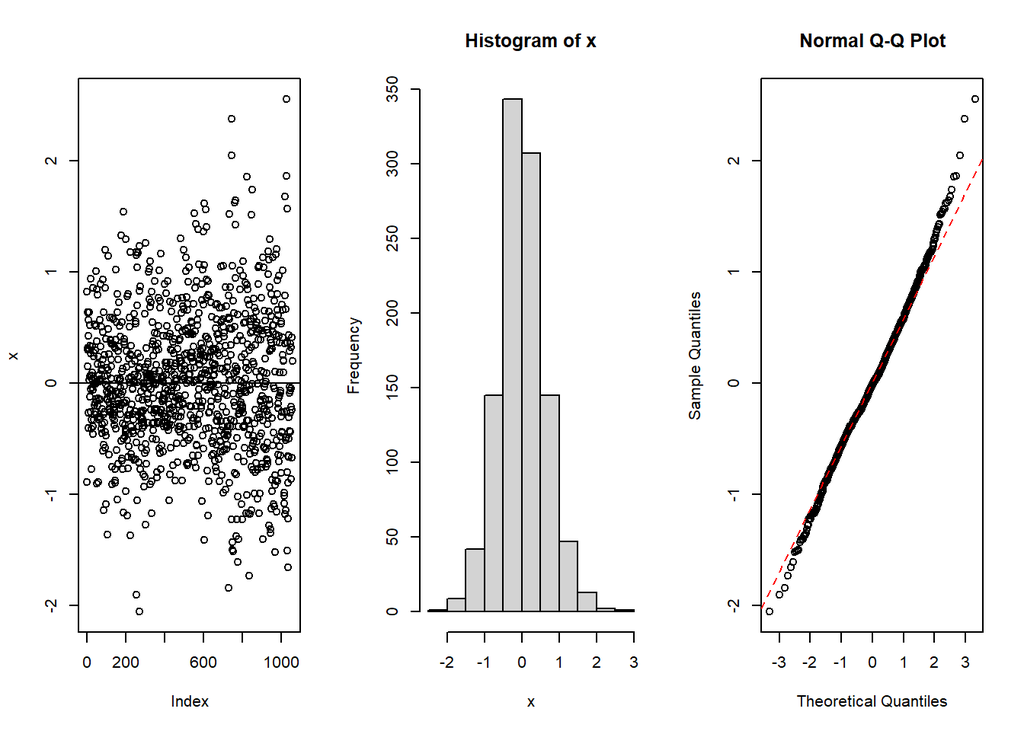

```
## [1] "Kurtosis=0.62252769325954"
## [1] "Skew=0.180396615854015"
```

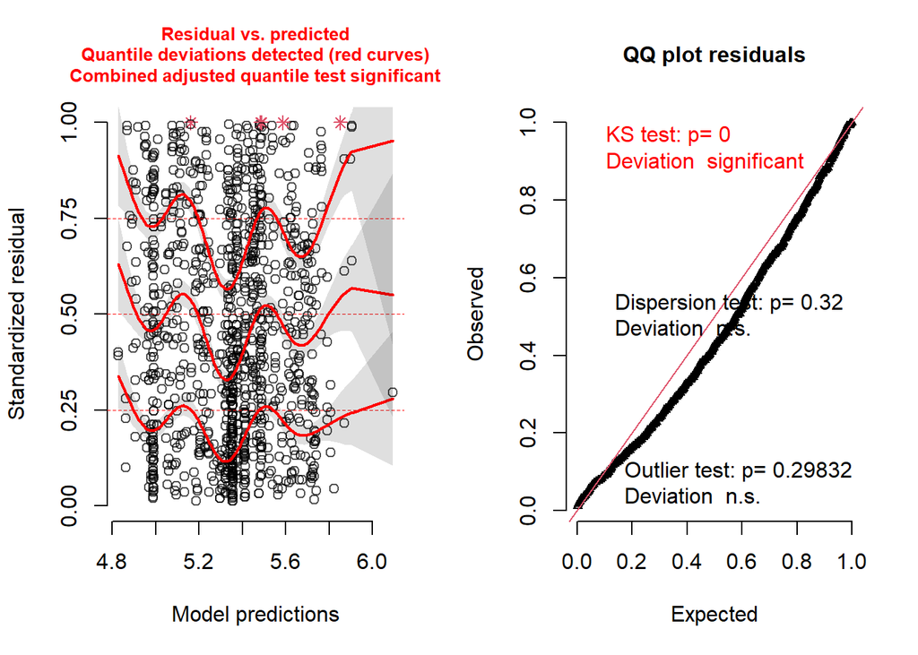

```
## Analysis of Deviance Table (Type II Wald chisquare tests)
##
## Response: sqrt(leaf_length)
##                   Chisq Df Pr(>Chisq)
## mainland_island 21.8619  1   2.93e-06 ***
## year_collected   6.5025  1    0.01077 *
## ---
## Signif. codes:  0 '***' 0.001 '**' 0.01 '*' 0.05 '.' 0.1 ' ' 1
```

**Mainland and island differences and year differences are significant.**

#### Emmeans: Leaf length

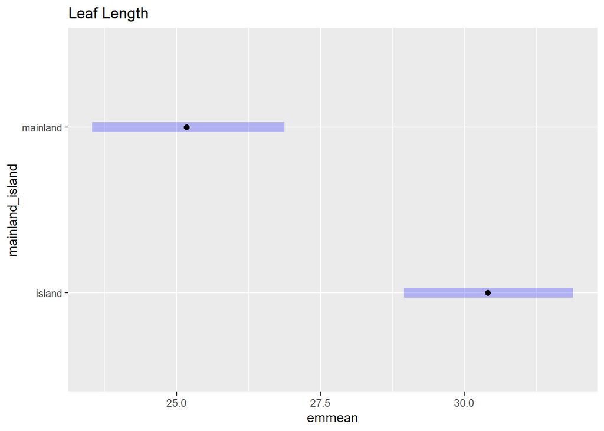

### Leaflet number

For this trait I used a glm model with a Poisson distribution:

**glm(number_of_leaflets ~ mainland_island + year_collected)**

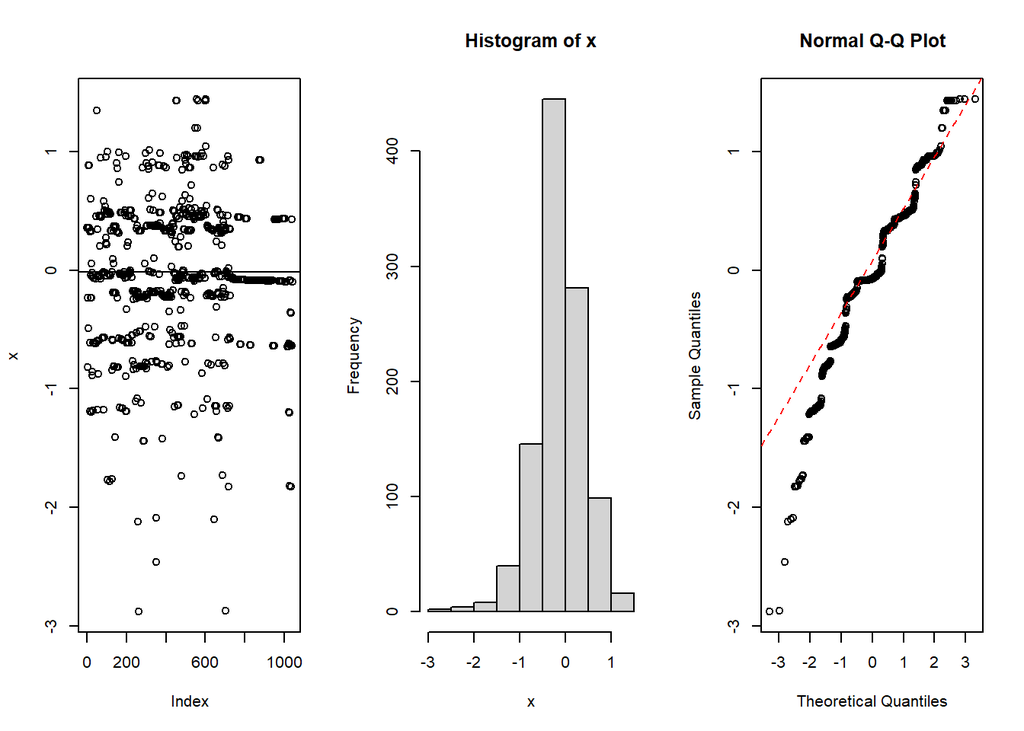

```
## [1] "Kurtosis=2.06742376370439"
## [1] "Skew=-0.665090322563763"
```

```
## DHARMa:plot used testOutliers with type = binomial for computational reasons (nObs > 500). Note that this method may not have inflated Type I error rates for integer-valued distributions. To get a more exact result, it is recommended to re-run testOutliers with type = 'bootstrap'. See ?testOutlie…
```

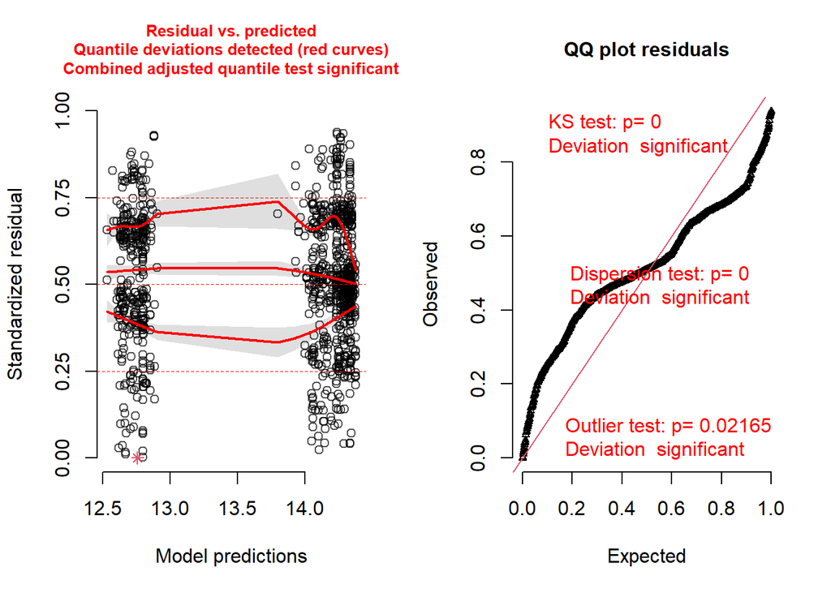

```
## Analysis of Deviance Table (Type II tests)
##
## Response: number_of_leaflets
##                 LR Chisq Df Pr(>Chisq)
## mainland_island   31.808  1  1.702e-08 ***
## year_collected     0.687  1      0.407
## ---
## Signif. codes:  0 '***' 0.001 '**' 0.01 '*' 0.05 '.' 0.1 ' ' 1
```

**Mainland and island differences are significant.**

#### Emmeans: Leaflet number

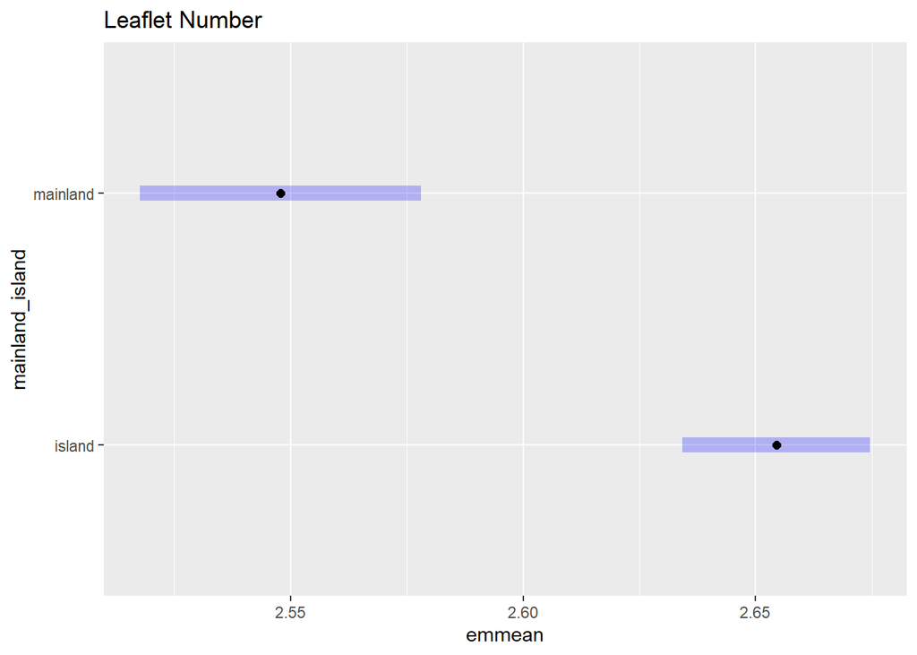